# Project 1

Hyunseok Lee

2024-09-18

# Data preprocessing

## Dataframe

```r
ncol(df)
```

```
## [1] 15
```

```r
nrow(df)
```

```
## [1] 634
```

```r
names(df)
```

```
##  [1] "subject_id"            "study"                 "cohort"
##  [4] "demo_race"             "demo_gender"           "demo_firstgen"
##  [7] "bedtime_mssd"          "TotalSleepTime"        "midpoint_sleep"
## [10] "frac_nights_with_data" "daytime_sleep"         "cum_gpa"
## [13] "term_gpa"              "term_units"            "Zterm_units_ZofZ"
```

```r
str(df)
```

```
## 'data.frame':    634 obs. of  15 variables:
##  $ subject_id           : int  185 158 209 102 174 184 255 265 343 137 ...
##  $ study                : int  5 5 5 5 5 5 5 5 5 5 ...
##  $ cohort               : chr  "lac1" "lac1" "lac1" "lac1" ...
##  $ demo_race            : int  1 0 1 0 1 1 1 1 1 1 ...
##  $ demo_gender          : int  1 1 1 1 1 1 1 1 0 1 ...
##  $ demo_firstgen        : int  0 0 0 1 0 0 0 0 0 0 ...
##  $ bedtime_mssd         : num  0.117 0.142 1.529 0.13 0.13 ...
##  $ TotalSleepTime       : num  432 392 344 393 423 ...
##  $ midpoint_sleep       : num  459 364 561 416 369 ...
##  $ frac_nights_with_data: num  0.862 1 0.793 1 0.655 ...
##  $ daytime_sleep        : num  24.2 13.1 15 54.6 10.5 ...
##  $ cum_gpa              : num  3 3.66 3.57 3.61 3.21 3.2 3.4 3.86 3.79 3.53 ...
##  $ term_gpa             : num  3.38 2.6 3.07 3.56 4 3.36 3.19 3.28 3.5 2.55 ...
##  $ term_units           : int  73 64 63 61 61 60 60 60 60 59 ...
##  $ Zterm_units_ZofZ     : num  4.06 2.48 2.31 1.96 1.96 ...
```

## Factorize columns

```r
# Change demo series and study as factors since it only contains 0,1 or 2.
df$demo_race<-factor(df$demo_race)
df$demo_gender <- factor(df$demo_gender)
df$demo_firstgen <- factor(df$demo_firstgen)
df$study <- factor(df$study)
summary(df)
```

```
##    subject_id      study      cohort          demo_race  demo_gender
##  Min.   :    1.0   1: 77   Length:634         0   :119   0   :263
##  1st Qu.:  178.0   2:140   Class :character   1   :514   1   :368
##  Median :  358.5   3:139   Mode  :character   NA's:  1   NA's:  3
##  Mean   :13005.9   4:147
##  3rd Qu.:  592.8   5:131
##  Max.   :99978.0
##
##  demo_firstgen  bedtime_mssd       TotalSleepTime  midpoint_sleep
##  0   :526      Min.   : 0.004505   Min.   :194.8   Min.   :247.1
##  1   :103      1st Qu.: 0.074694   1st Qu.:366.9   1st Qu.:345.2
##  2   :  1      Median : 0.135007   Median :400.4   Median :388.2
##  NA's:  4      Mean   : 0.451688   Mean   :397.3   Mean   :398.7
##                3rd Qu.: 0.291698   3rd Qu.:430.1   3rd Qu.:437.7
##                Max.   :20.849225   Max.   :587.7   Max.   :724.7
##
##  frac_nights_with_data daytime_sleep        cum_gpa         term_gpa
##  Min.   :0.2143        Min.   :  2.269   Min.   :1.210   Min.   :0.350
##  1st Qu.:0.8214        1st Qu.: 23.098   1st Qu.:3.232   1st Qu.:3.233
##  Median :0.9322        Median : 34.982   Median :3.558   Median :3.556
##  Mean   :0.8674        Mean   : 41.164   Mean   :3.466   Mean   :3.450
##  3rd Qu.:1.0000        3rd Qu.: 51.249   3rd Qu.:3.790   3rd Qu.:3.810
##  Max.   :1.0000        Max.   :292.304   Max.   :4.000   Max.   :4.000
##
##    term_units    Zterm_units_ZofZ
##  Min.   : 5.00   Min.   :-3.98252
##  1st Qu.:15.00   1st Qu.:-0.55104
##  Median :17.00   Median : 0.04121
##  Mean   :29.39   Mean   : 0.00000
##  3rd Qu.:48.00   3rd Qu.: 0.56027
##  Max.   :73.00   Max.   : 4.05529
##  NA's   :147     NA's   :147
```

## Delete and select cols and rows

```r
#Don't need uninformative cols
df<-df %>% select(.,-subject_id, -cohort, -term_units)

# Delete 'NA' rows
colSums(is.na(df))
```

```
##                 study             demo_race           demo_gender
##                     0                     1                     3
##         demo_firstgen          bedtime_mssd        TotalSleepTime
##                     4                     0                     0
##        midpoint_sleep frac_nights_with_data         daytime_sleep
##                     0                     0                     0
##               cum_gpa              term_gpa      Zterm_units_ZofZ
##                     0                     0                   147
```

```r
df.new <- df %>% filter(!is.na(demo_race) & !is.na(demo_gender) & !is.na(demo_firstgen))

# Delete firstgen == 2 outlier
df.new <- df.new %>% filter(!(demo_firstgen == 2))

dim(df.new)
```

```
## [1] 625  12
```

[output not shown]

## Outliers

```r
# Detect outliers
detectoutlier <- function(x) {
  # Remove missing values
  x <- x[!is.na(x)]
  mean_val <- mean(x)
  sd_val <- sd(x)
  # Identify outliers based on z-scores
  abs(x - mean_val) > (3 * sd_val)
}
# Remove outliers
removeoutlier <- function(dataframe, columns=names(dataframe)) {
  for (col in columns) {
    dataframe <- dataframe[!detectoutlier(dataframe[[col]]),]
  }
  print(dataframe)
}
# find how many outliers in each variable except target variable
sum(detoutlier(df.new$bedtime_mssd)=='TRUE')
sum(detoutlier(df.new$TotalSleepTime)=='TRUE')
sum(detoutlier(df.new$midpoint_sleep)=='TRUE')
sum(detoutlier(df.new$frac_nights_with_data)=='TRUE')
sum(detoutlier(df.new$daytime_sleep)=='TRUE')
sum(detoutlier(df.new$cum_gpa)=='TRUE')
sum(detoutlier(df.new$Zterm_units_ZofZ)=='TRUE')

# remove all outliers
df.new1 <- removeoutlier(df.new, c('bedtime_mssd','TotalSleepTime', 'midpoint_sleep', 'frac_nights_with_data', 'daytime_sleep', 'cum_gpa', 'Zterm_units_ZofZ'))
```

Didn’t include this ‘outlier’ code, but willing to include if needed.

## Plots

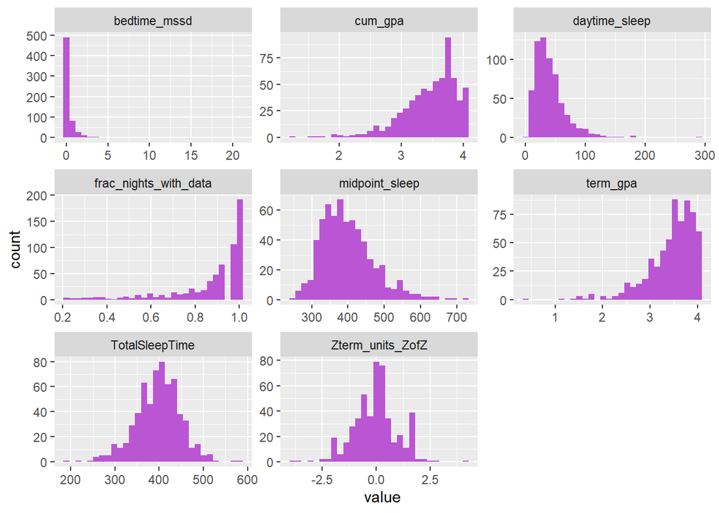

```r
#Quant plots
df.new %>% select(.,-study, -demo_race, -demo_gender, -demo_firstgen) %>% gather(.) -> df.quant
ggplot(data=df.quant,mapping=aes(x=value)) +
  geom_histogram(fill="mediumorchid") +
  facet_wrap(~key,scales='free')
```

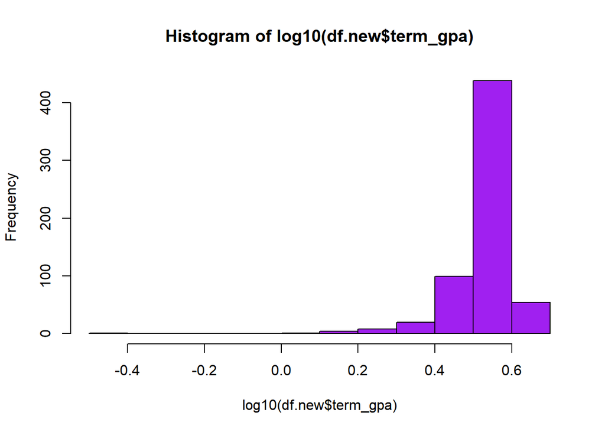

```r
hist(log10(df.new$term_gpa),col="purple")#doesn't look symmetric, so let it go.
```

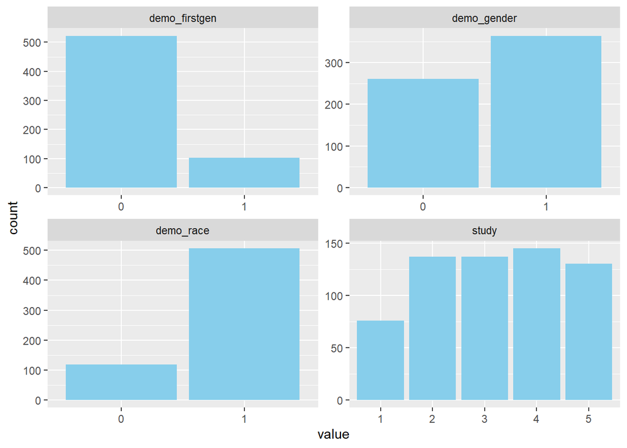

```r
# Cat plots
df.new %>% select(., study, demo_race, demo_gender, demo_firstgen) %>% gather(.) -> df.cat
ggplot(data=df.cat,mapping=aes(x=value)) +
  geom_bar(fill="skyblue") +
  facet_wrap(~key,scales="free")
```

## Plot with response variable

For better understanding I separate response variable and other categorical + quantitative variables.

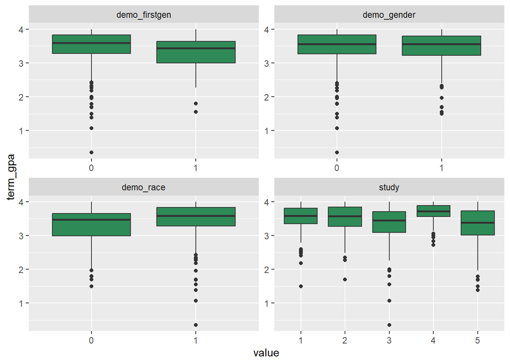

```r
# Categorical variables
ggplot(data=df.cat,mapping=aes(x=value,y=rep(df.new$term_gpa,4))) +
  geom_boxplot(fill="seagreen") +
  facet_wrap(~key,scales="free") +
  ylab("term_gpa")
```

The term_gpa looks similar for both gender, firstgen and race. In study plot, 4(Notre Dame University) clustered in high term_gpa compare with others. 5(CMU) has the highest variation. Most of schools has similar output in bedtime_mssd vs term_gpa but study 4 is well clustered.

### Total Sleep Time vs Term GPA by Gender

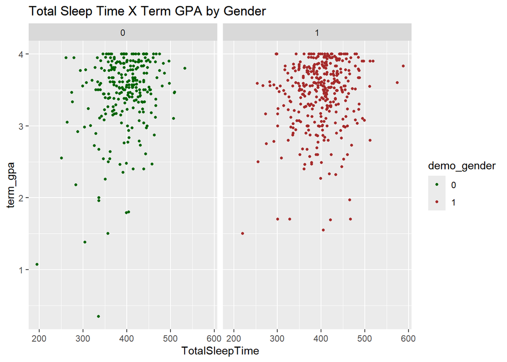

```r
ggplot(df.new, aes(x = TotalSleepTime, y = term_gpa, color = demo_gender)) + geom_point(size = 1) +
 facet_wrap(~ demo_gender) + scale_color_manual(values = c('darkgreen', 'brown')) +
  labs(title = "Total Sleep Time X Term GPA by Gender")
```

Both gender looks similiar totalsleeptime and term_gpa, but male group has some outliers with low term_gpa.

### Total Sleep Time vs Term GPA by study

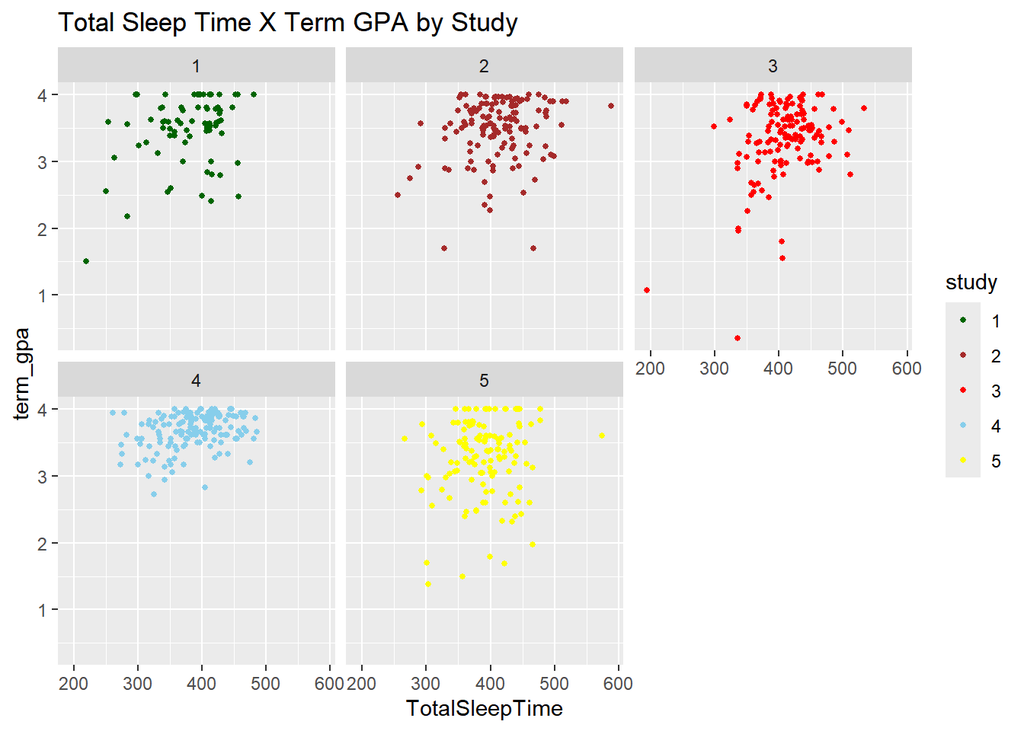

```r
ggplot(df.new, aes(x = TotalSleepTime, y = term_gpa, color = study)) + geom_point(size = 1) +
 facet_wrap(~ study) + scale_color_manual(values = c('darkgreen', 'brown','red', 'skyblue','yellow')) +
  labs(title = "Total Sleep Time X Term GPA by Study")
```

study looks similar with study “5” has high variance and “4” has low variance.

### Midtime sleep X Term GPA by study

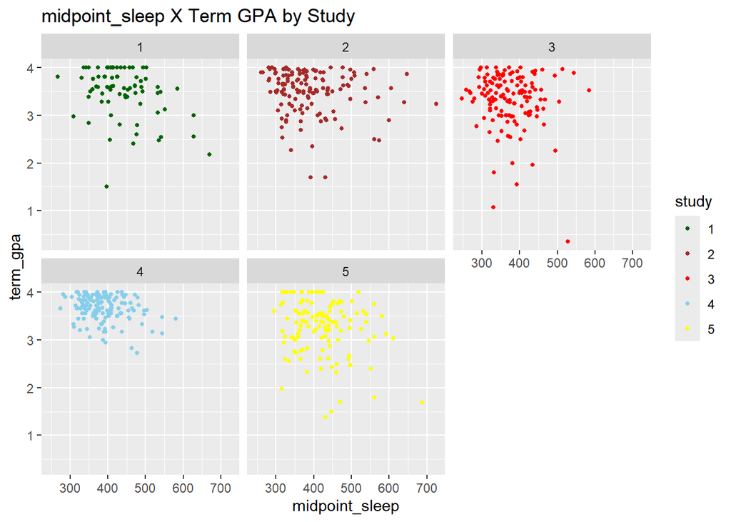

```r
ggplot(df.new, aes(x = midpoint_sleep, y = term_gpa, color = study)) + geom_point(size = 1) +
 facet_wrap(~ study) + scale_color_manual(values = c('darkgreen', 'brown','red', 'skyblue','yellow')) +
  labs(title = "midpoint_sleep X Term GPA by Study")
```

Midtime_sleep looks very simliar with the totalsleep charts.

### Bedtime_mssd vs Term GPA by study

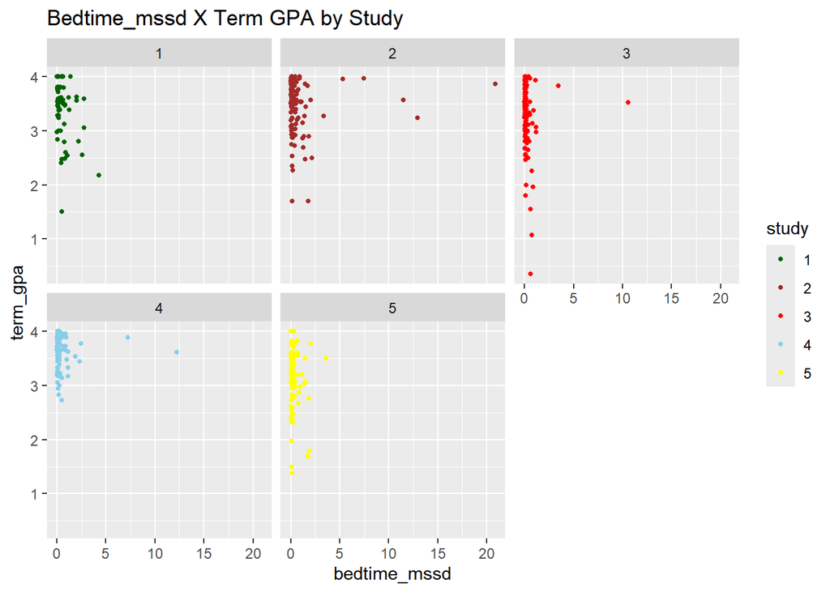

```r
ggplot(df.new, aes(x = bedtime_mssd, y = term_gpa, color = study)) + geom_point(size = 1) +
 facet_wrap(~ study) + scale_color_manual(values = c('darkgreen', 'brown','red', 'skyblue','yellow')) +
  labs(title = "Bedtime_mssd X Term GPA by Study")
```

Most students have similiar sleep time but there are some outliers in study “2,3,4”.

### Quantitative variables

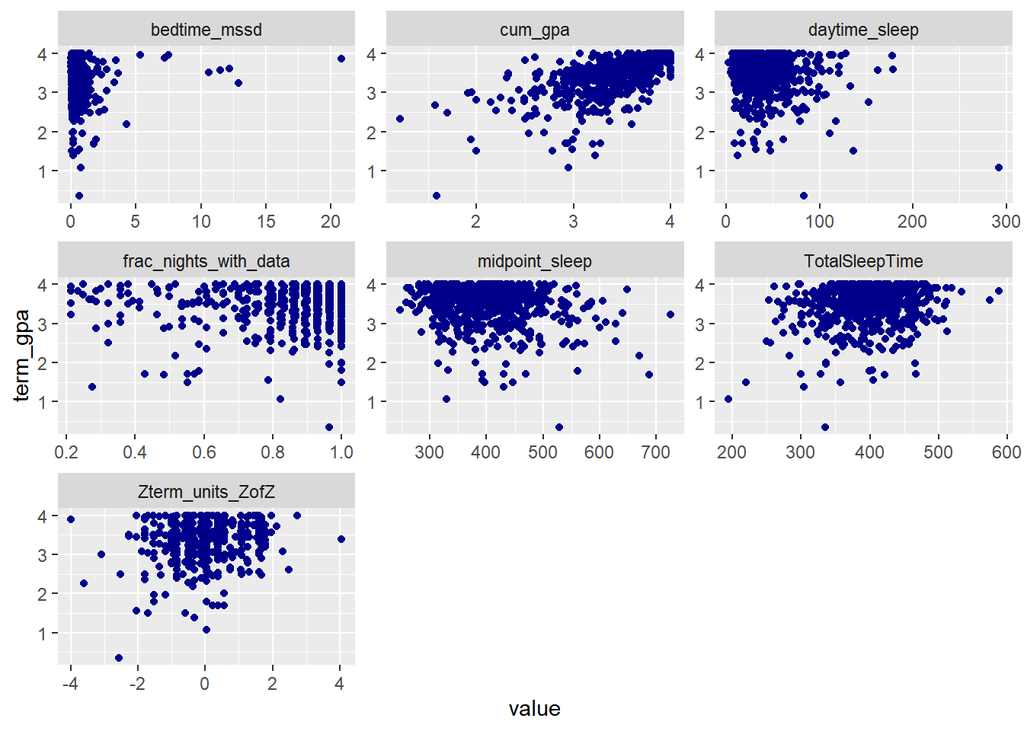

```r
df.new %>% select(.,-study, -demo_race, -demo_gender, -demo_firstgen, -term_gpa) %>% gather(.) %>% ggplot(.,mapping=aes(x=value,y=rep(df.new$term_gpa,7))) +
  geom_point(col="darkblue") +
  facet_wrap(~key,scales="free") +
  ylab("term_gpa")
```

For categorical variables (firstgen, race, gender, and study groups)  
Most means are look similiar to others. but study groups are slightly different. 4(Notre Dame university) is the highest term_gpa compare with others.  
For numerical variables  
The scattle plots shows that the most student have lower bedtime variability with high term_gpa, higher cum_gpa has higher term_gpa. Most of student take 10-40 mins daytime sleep. Also, midtime_sleep and Totalsleeptime are shown that the most students take 300-500 and 350-450 mins of sleep. last, except all NA’s, the student’s load relative to the average amount of units(Zterm_units) are clustered in 0.

## Correlation

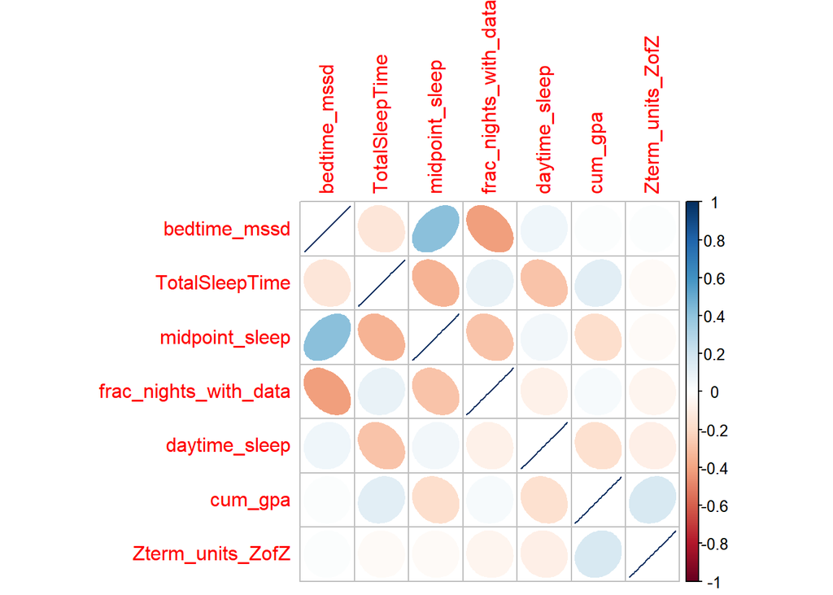

```r
# correlation without all NA's
# Without response variable
df.new %>% select(.,-study, -demo_race, -demo_gender, -demo_firstgen, -term_gpa) %>% na.omit() %>% cor(.) %>% corrplot(.,method="ellipse")
```

```r
df.new %>% select(.,-study, -demo_race, -demo_gender, -demo_firstgen, -term_gpa) %>% na.omit() -> df.num
cor(df.num)
```

```
##                       bedtime_mssd TotalSleepTime midpoint_sleep
## bedtime_mssd            1.00000000    -0.13427597     0.41631890
## TotalSleepTime         -0.13427597     1.00000000    -0.34386880
## midpoint_sleep          0.41631890    -0.34386880     1.00000000
## frac_nights_with_data  -0.41300109     0.09454005    -0.28200627
## daytime_sleep           0.06363412    -0.28955321     0.05329785
## cum_gpa                 0.01410479     0.12876629    -0.17495486
## Zterm_units_ZofZ        0.01741981    -0.02339798    -0.02452849
##                       frac_nights_with_data daytime_sleep     cum_gpa
## bedtime_mssd                    -0.41300109    0.06363412  0.01410479
## TotalSleepTime                   0.09454005   -0.28955321  0.12876629
## midpoint_sleep                  -0.28200627    0.05329785 -0.17495486
## frac_nights_with_data            1.00000000   -0.07631617  0.03117484
## daytime_sleep                   -0.07631617    1.00000000 -0.16961494
## cum_gpa                          0.03117484   -0.16961494  1.00000000
## Zterm_units_ZofZ                -0.05443360   -0.08097767  0.16458708
##                       Zterm_units_ZofZ
## bedtime_mssd                0.01741981
## TotalSleepTime             -0.02339798
## midpoint_sleep             -0.02452849
## frac_nights_with_data      -0.05443360
## daytime_sleep              -0.08097767
## cum_gpa                     0.16458708
## Zterm_units_ZofZ            1.00000000
```

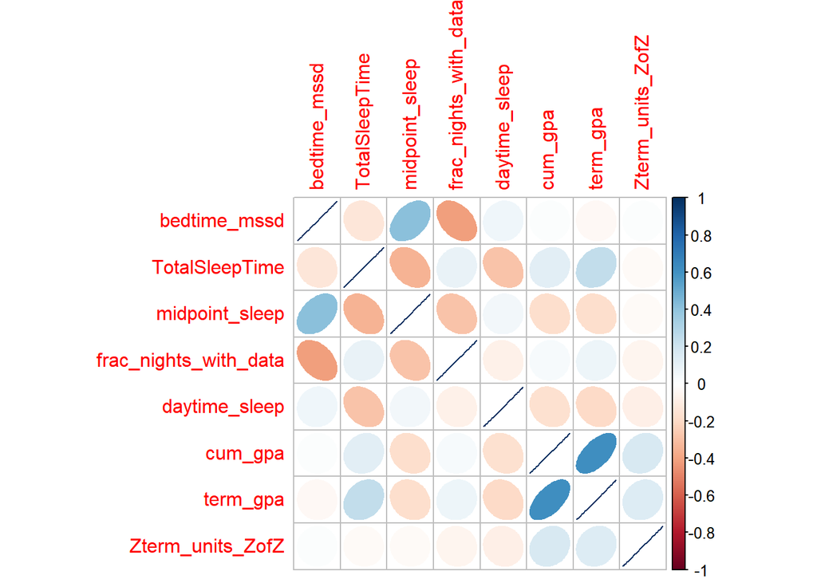

```r
# With response variable
df.new %>% select(.,-study, -demo_race, -demo_gender, -demo_firstgen) %>% na.omit() %>% cor(.) %>% corrplot(.,method="ellipse")
```

```r
df.new %>% select(.,-study, -demo_race, -demo_gender, -demo_firstgen) %>% na.omit() -> df.wterm
cor(df.wterm)
```

```
##                       bedtime_mssd TotalSleepTime midpoint_sleep
## bedtime_mssd            1.00000000    -0.13427597     0.41631890
## TotalSleepTime         -0.13427597     1.00000000    -0.34386880
## midpoint_sleep          0.41631890    -0.34386880     1.00000000
## frac_nights_with_data  -0.41300109     0.09454005    -0.28200627
## daytime_sleep           0.06363412    -0.28955321     0.05329785
## cum_gpa                 0.01410479     0.12876629    -0.17495486
## term_gpa               -0.03215239     0.24529779    -0.17824806
## Zterm_units_ZofZ        0.01741981    -0.02339798    -0.02452849
##                       frac_nights_with_data daytime_sleep     cum_gpa
## bedtime_mssd                    -0.41300109    0.06363412  0.01410479
## TotalSleepTime                   0.09454005   -0.28955321  0.12876629
## midpoint_sleep                  -0.28200627    0.05329785 -0.17495486
## frac_nights_with_data            1.00000000   -0.07631617  0.03117484
## daytime_sleep                   -0.07631617    1.00000000 -0.16961494
## cum_gpa                          0.03117484   -0.16961494  1.00000000
## term_gpa                         0.07065932   -0.19178966  0.61476359
## Zterm_units_ZofZ                -0.05443360   -0.08097767  0.16458708
##                          term_gpa Zterm_units_ZofZ
## bedtime_mssd          -0.03215239       0.01741981
## TotalSleepTime         0.24529779      -0.02339798
## midpoint_sleep        -0.17824806      -0.02452849
## frac_nights_with_data  0.07065932      -0.05443360
## daytime_sleep         -0.19178966      -0.08097767
## cum_gpa                0.61476359       0.16458708
## term_gpa               1.00000000       0.14342545
## Zterm_units_ZofZ       0.14342545       1.00000000
```